# Mexican Agriculture

Galactor

27/8/2018

## Mexican Agriculture

### Intro

```r
library(dplyr)
```

```r
library(ggplot2)
library(magrittr)
library(tidyr)
library(knitr)
library(mxmaps)
```

```r
#We load the data imported directly from the Ministry of Agriculture´s website. We will analyse 2017
mex <- read.csv(file="Agro_2017.csv", header=TRUE, sep=",")
```

```r
mex %>% select(Nomcultivo) %>% unique %>% arrange (Nomcultivo) %>% kable("html",row.names = TRUE)
```

|  | Nomcultivo |
| --- | --- |
| 1 | Aceituna |
| 2 | Acelga |
| 3 | Achiote |
| 4 | Agapando |
| 5 | Agave |
| 6 | Aguacate |
| 7 | Ajo |
| 8 | Ajonjoli |
| 9 | Albahaca |
| 10 | Albricia |
| 11 | Alcachofa |
| 12 | Alcatraz |
| 13 | Alfalfa achicalada |
| 14 | Alfalfa verde |
| 15 | Algarrobo |
| 16 | Algodon hueso |
| 17 | Alheli |
| 18 | Alpiste |
| 19 | Alpiste ornamental |
| 20 | Alstroemeria |
| 21 | Amaranto |
| 22 | Anis |
| 23 | Anturios |
| 24 | Apio |
| 25 | Arandano |
| 26 | arbol de navidad |
| 27 | Aretillo |
| 28 | Arrayan |
| 29 | Arroz palay |
| 30 | Arvejon |

[output cut: 274 more lines]

There are more than 300 different kinds of crops grown in Mexico. Maize is a very important crop for Mexicans, we would like to know which states have the largest production.

```r
mex %>% select(Nomcultivo, Idcultivo, Volumenproduccion) %>%  group_by(Nomcultivo) %>% summarise(total=sum(Volumenproduccion)) %>% arrange(desc(total))
```

```
## # A tibble: 304 x 2
##    Nomcultivo                  total
##    <fct>                       <dbl>
##  1 Fresa                   205441061
##  2 Plantero de tabaco      133746210
##  3 Cana de azucar           56954993
##  4 Pastos y praderas        53939071
##  5 Maiz grano               27762481
##  6 Alfalfa verde            21055313
##  7 Nochebuena               18055674
##  8 Maiz forrajero en verde  16669014
##  9 Rosa                     13423497
## 10 Crisantemo               12045077
## # ... with 294 more rows
```

Measured in tons, strawberry and sugar cane have the largest production. We excluded tobacco plants since they are measured in plants rather than tons.

```r
mex %>% select(Nomcultivo, Idcultivo, Valorproduccion) %>%  group_by(Nomcultivo) %>% summarise(total=sum(Valorproduccion)) %>% arrange(desc(total))
```

```
## # A tibble: 304 x 2
##    Nomcultivo                    total
##    <fct>                         <dbl>
##  1 Maiz grano             100206306148
##  2 Aguacate                39705966215
##  3 Cana de azucar          38411928281
##  4 Tomate rojo (jitomate)  25483434733
##  5 Pastos y praderas       23002527086
##  6 Chile verde             22566696756
##  7 Frijol                  16375786797
##  8 Sorgo grano             15306951790
##  9 Agave                   14996383289
## 10 Trigo grano             13288954142
## # ... with 294 more rows
```

Measured in value($), maize and avocado have the most valuable production.

### Maize

```r
#Note that in this analysis we include the 3 types of maize available in the data set

maize1 <- mex %>% select(Nomcultivo, Nomestado, Idcultivo, Volumenproduccion, Idestado) %>% filter(Idcultivo==c("7470000", "7490000", "7510000")) %>% group_by(Nomestado, Idestado) %>% summarise(value=sum(Volumenproduccion)) %>% arrange(desc(value))

maize1
```

```
## # A tibble: 32 x 3
## # Groups: Nomestado [32]
##    Nomestado  Idestado   value
##    <fct>         <int>   <dbl>
##  1 Jalisco          14 2419952
##  2 Sinaloa          25 1975159
##  3 Mexico           15 1104508
##  4 Chihuahua         8  980273
##  5 Zacatecas        32  944113
##  6 Durango          10  816460
##  7 Guanajuato       11  770729
##  8 Queretaro        22  601094
##  9 Michoacan        16  588310
## 10 Coahuila          5  569322
## # ... with 22 more rows
```

Jalisco and Sinaloa are the largest maize producers in Mexico.

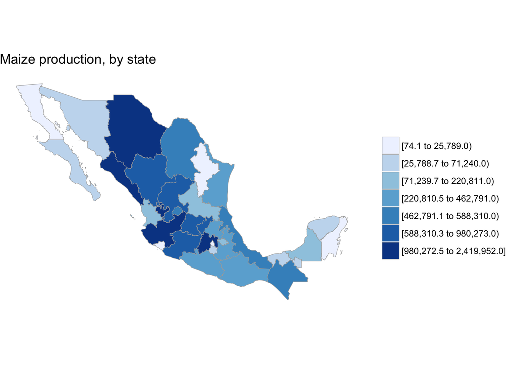

```r
data("maize1")
maize1$region <- maize1$Idestado
mxstate_choropleth(maize1, title = "Maize production, by state")
```

```r
maize2 <- mex %>% select(Nomcultivo, Nomestado, Idcultivo, Volumenproduccion, Nommunicipio, Idestado, Idmunicipio) %>% filter(Idcultivo==c("7470000", "7490000", "7510000")) %>% group_by(Nomestado, Nommunicipio, Idestado, Idmunicipio) %>% summarise(value=sum(Volumenproduccion)) %>% arrange(desc(value))

maize2
```

```
## # A tibble: 1,274 x 5
## # Groups: Nomestado, Nommunicipio, Idestado [1,274]
##    Nomestado Nommunicipio          Idestado Idmunicipio  value
##    <fct>     <fct>                    <int>       <int>  <dbl>
##  1 Sinaloa   Guasave                     25          11 609015
##  2 Jalisco   Tepatitlan de Morelos       14          93 467682
##  3 Chihuahua Cuauhtemoc                   8          17 442159
##  4 Coahuila  Matamoros                    5          17 413110
##  5 Queretaro El Marques                  22          11 400623
##  6 Durango   Lerdo                       10          12 392897
##  7 Zacatecas Villanueva                  32          55 346621
##  8 Sinaloa   Culiacan                    25           6 334510
##  9 Sinaloa   Navolato                    25          18 271238
## 10 Sinaloa   Elota                       25           8 234308
## # ... with 1,264 more rows
```

We can see that municipalities producing the highest are located at Sinaloa, Jalisco Chihuahua and Coahuila mainly.

### Avocado

```r
avo1 <- mex %>% select(Nomcultivo, Nomestado, Idcultivo, Volumenproduccion, Idestado) %>% filter(Idcultivo==c("5060000")) %>% group_by(Nomestado, Idestado) %>% summarise(value=sum(Volumenproduccion)) %>% arrange(desc(value))

avo1
```

```
## # A tibble: 27 x 3
## # Groups: Nomestado [27]
##    Nomestado Idestado   value
##    <fct>        <int>   <dbl>
##  1 Michoacan       16 1565896
##  2 Jalisco         14  169688
##  3 Mexico          15  108768
##  4 Nayarit         18   49246
##  5 Morelos         17   34846
##  6 Guerrero        12   23586
##  7 Puebla          21   16842
##  8 Chiapas          7   12009
##  9 Yucatan         31   10772
## 10 Oaxaca          20    9097
## # ... with 17 more rows
```

Michoacan clearly dominates the national avocado production

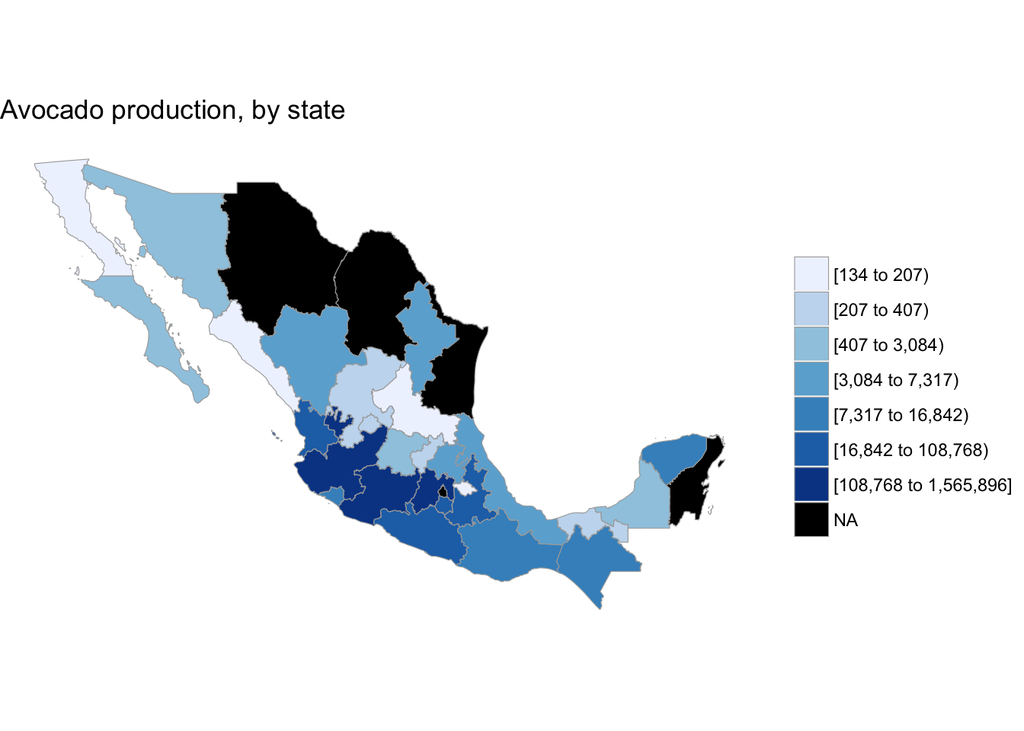

```r
avo1$region <- avo1$Idestado
mxstate_choropleth(avo1, title = "Avocado production, by state")
```

```r
mex %>% select(Nomcultivo, Nomestado, Idcultivo, Volumenproduccion, Nommunicipio) %>% filter(Idcultivo==c("5060000")) %>% group_by(Nomestado, Nommunicipio) %>% summarise(total=sum(Volumenproduccion)) %>% arrange(desc(total))
```

```
## # A tibble: 585 x 3
## # Groups: Nomestado [27]
##    Nomestado Nommunicipio           total
##    <fct>     <fct>                  <dbl>
##  1 Michoacan Tancitaro             218974
##  2 Michoacan Salvador Escalante    173912
##  3 Michoacan Tacambaro             173595
##  4 Michoacan Ario                  167098
##  5 Michoacan Uruapan               153505
##  6 Michoacan Periban               143054
##  7 Michoacan Nuevo Parangaricutiro  69995
##  8 Michoacan Los Reyes              63623
##  9 Michoacan "Ting\x9findin"        59704
## 10 Michoacan Turicato               46486
## # ... with 575 more rows
```

No surprise that the majority of the municipalities included in the list are locates at Michoacan.

### Strawberry

```r
str1 <- mex %>% select(Nomcultivo, Nomestado, Idcultivo, Volumenproduccion, Idestado) %>% filter(Idcultivo==c("6820000")) %>% group_by(Nomestado, Idestado) %>% summarise(value=sum(Volumenproduccion)) %>% arrange(desc(value))

str1
```

```
## # A tibble: 15 x 3
## # Groups: Nomestado [15]
##    Nomestado           Idestado     value
##    <fct>                  <int>     <dbl>
##  1 Michoacan                 16 484936
##  2 Baja California            2  91660
##  3 Guanajuato                11  57667
##  4 Baja California Sur        3   9985
##  5 Mexico                    15   7825
##  6 Aguascalientes             1   3336
##  7 Jalisco                   14   1690
##  8 Puebla                    21    516
##  9 Zacatecas                 32    301
## 10 Oaxaca                    20    172
## 11 Tlaxcala                  29    135
## 12 Morelos                   17     95.9
## 13 Chihuahua                  8     74.8
## 14 Veracruz                  30     38.2
## 15 San Luis Potosi           24      3.40
```

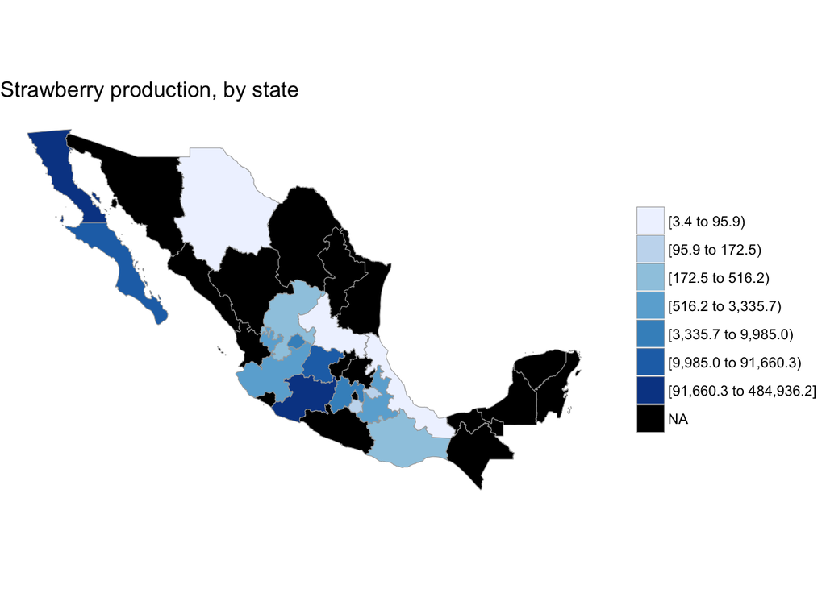

```r
str1$region <- str1$Idestado
mxstate_choropleth(str1, title = "Strawberry production, by state")
```

Michoacan clearly dominates strawberry production in Mexico

```r
mex %>% select(Nomcultivo, Nomestado, Idcultivo, Volumenproduccion, Nommunicipio) %>% filter(Idcultivo==c("6820000")) %>% group_by(Nomestado, Nommunicipio) %>% summarise(total=sum(Volumenproduccion)) %>% arrange(desc(total))
```

```
## # A tibble: 75 x 3
## # Groups: Nomestado [15]
##    Nomestado       Nommunicipio   total
##    <fct>           <fct>          <dbl>
##  1 Michoacan       Zamora        174952
##  2 Baja California Ensenada       91660
##  3 Michoacan       Tangancicuaro  83383
##  4 Michoacan       Jacona         71530
##  5 Michoacan       Ixtlan         34410
##  6 Guanajuato      Irapuato       33109
##  7 Michoacan       Chilchota      27303
##  8 Michoacan       Panindicuaro   17910
##  9 Michoacan       Angamacutiro   10880
## 10 Michoacan       Maravatio      10191
## # ... with 65 more rows
```

### Peppers

```r
ch1 <-mex %>% select(Nomcultivo, Nomestado, Idcultivo, Volumenproduccion,Idestado) %>% filter(Idcultivo==c("6120000")) %>% group_by(Nomestado, Idestado) %>% summarise(value=sum(Volumenproduccion)) %>% arrange(desc(value))

ch1
```

```
## # A tibble: 32 x 3
## # Groups: Nomestado [32]
##    Nomestado           Idestado  value
##    <fct>                  <int>  <dbl>
##  1 Sinaloa                   25 770993
##  2 Chihuahua                  8 697418
##  3 Sonora                    26 187470
##  4 Zacatecas                 32 150416
##  5 Michoacan                 16 146817
##  6 Jalisco                   14 143686
##  7 Guanajuato                11 104776
##  8 San Luis Potosi           24  86108
##  9 Baja California Sur        3  59633
## 10 Tamaulipas                28  50561
## # ... with 22 more rows
```

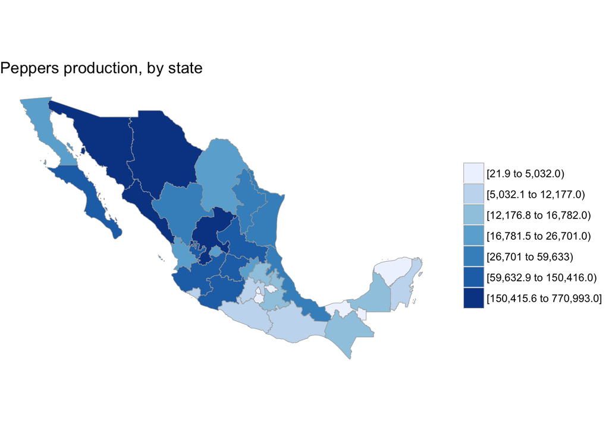

```r
ch1$region <- ch1$Idestado
mxstate_choropleth(ch1, title = "Peppers production, by state")
```

```r
mex %>% select(Nomcultivo, Nomestado, Idcultivo, Volumenproduccion, Nommunicipio) %>% filter(Idcultivo==c("6120000")) %>% group_by(Nomestado, Nommunicipio) %>% summarise(total=sum(Volumenproduccion)) %>% arrange(desc(total))
```

```
## # A tibble: 620 x 3
## # Groups: Nomestado [32]
##    Nomestado Nommunicipio  total
##    <fct>     <fct>         <dbl>
##  1 Sinaloa   Culiacan     158295
##  2 Sinaloa   Escuinapa    148405
##  3 Sinaloa   Navolato     140360
##  4 Zacatecas Fresnillo    134410
##  5 Chihuahua Ascension    118835
##  6 Chihuahua Camargo      110000
##  7 Chihuahua Janos         97800
##  8 Sinaloa   Elota         75833
##  9 Chihuahua Delicias      75335
## 10 Michoacan Yurecuaro     71700
## # ... with 610 more rows
```

### Sugar Cane

```r
sug1<- mex %>% select(Nomcultivo, Nomestado, Idcultivo, Volumenproduccion, Idestado) %>% filter(Idcultivo==c("5820000")) %>% group_by(Nomestado, Idestado) %>% summarise(value=sum(Volumenproduccion)) %>% arrange(desc(value))

sug1
```

```
## # A tibble: 16 x 3
## # Groups: Nomestado [16]
##    Nomestado       Idestado    value
##    <fct>              <int>    <dbl>
##  1 Veracruz              30 21116194
##  2 Jalisco               14  7439307
##  3 San Luis Potosi       24  4636468
##  4 Oaxaca                20  3768444
##  5 Tamaulipas            28  3047552
##  6 Chiapas                7  2930695
##  7 Nayarit               18  2687865
##  8 Tabasco               27  2453374
##  9 Morelos               17  2037144
## 10 Puebla                21  1761494
## 11 Quintana Roo          23  1448275
## 12 Michoacan             16  1413323
## 13 Colima                 6  1075991
## 14 Campeche               4   743493
## 15 Sinaloa               25   387264
## 16 Mexico                15     8110
```

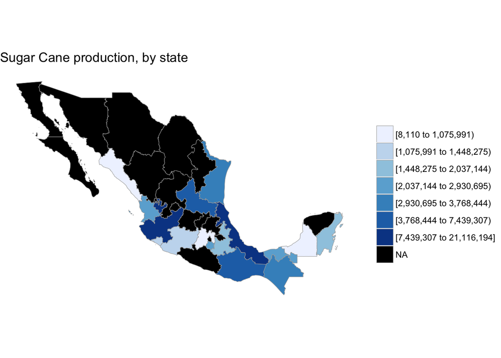

```r
sug1$region <- sug1$Idestado
mxstate_choropleth(sug1, title = "Sugar Cane production, by state")
```

Veracruz and Jalisco are the largest sugar cane producers.

```r
mex %>% select(Nomcultivo, Nomestado, Idcultivo, Volumenproduccion, Nommunicipio) %>% filter(Idcultivo==c("5820000")) %>% group_by(Nomestado, Nommunicipio) %>% summarise(total=sum(Volumenproduccion)) %>% arrange(desc(total))
```

```
## # A tibble: 263 x 3
## # Groups: Nomestado [16]
##    Nomestado       Nommunicipio                 total
##    <fct>           <fct>                        <dbl>
##  1 San Luis Potosi Ciudad Valles              1860857
##  2 Tabasco         Cardenas                   1685618
##  3 Veracruz        Panuco                     1484270
##  4 Quintana Roo    Othon P. Blanco            1448275
##  5 Veracruz        Tres Valles                1297206
##  6 Veracruz        Tierra Blanca              1225847
##  7 Veracruz        Cosamaloapan de Carpio     1214453
##  8 Oaxaca          San Juan Bautista Tuxtepec 1162166
##  9 Oaxaca          Acatlan de Perez Figueroa  1104033
## 10 Veracruz        El Higo                     913320
## # ... with 253 more rows
```

### Cotton

```r
cot1 <- mex %>% select(Nomcultivo, Nomestado, Idcultivo, Volumenproduccion, Idestado) %>% filter(Idcultivo==c("5190000")) %>% group_by(Nomestado, Idestado) %>% summarise(value=sum(Volumenproduccion)) %>% arrange(desc(value))

cot1
```

```
## # A tibble: 6 x 3
## # Groups: Nomestado [6]
##   Nomestado       Idestado  value
##   <fct>              <int>  <dbl>
## 1 Chihuahua              8 708332
## 2 Baja California        2 145176
## 3 Coahuila               5  81926
## 4 Tamaulipas            28  32209
## 5 Sonora                26  27998
## 6 Durango               10  13462
```

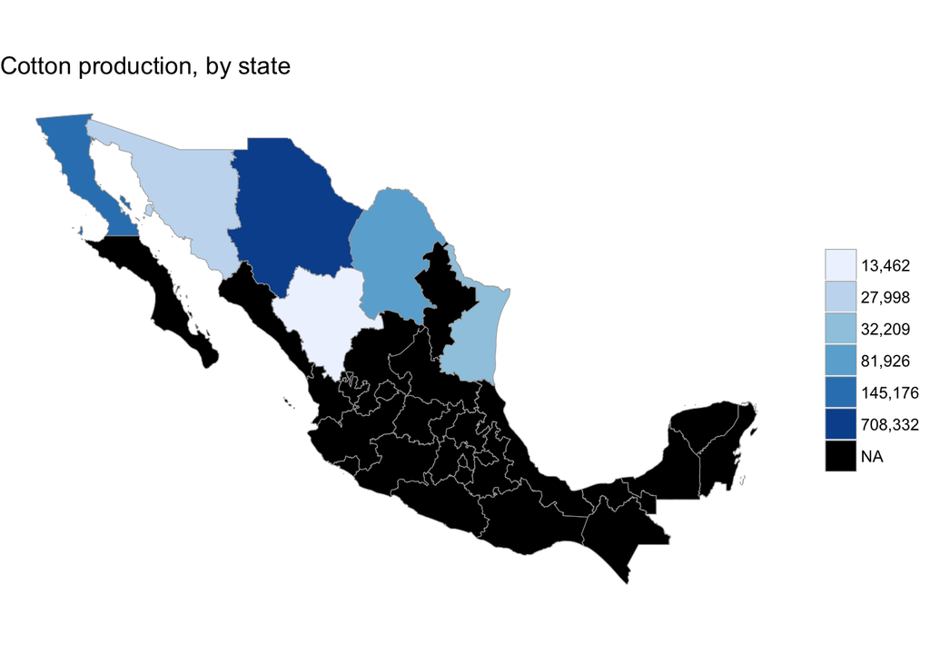

```r
cot1$region <- cot1$Idestado
mxstate_choropleth(cot1, title = "Cotton production, by state")
```

Chihuahua and Baja California lead the list in cotton production

```r
mex %>% select(Nomcultivo, Nomestado, Idcultivo, Volumenproduccion, Nommunicipio) %>% filter(Idcultivo==c("5190000")) %>% group_by(Nomestado, Nommunicipio) %>% summarise(total=sum(Volumenproduccion)) %>% arrange(desc(total))
```

```
## # A tibble: 49 x 3
## # Groups: Nomestado [6]
##    Nomestado       Nommunicipio  total
##    <fct>           <fct>         <dbl>
##  1 Chihuahua       Buenaventura 153152
##  2 Baja California Mexicali     145176
##  3 Chihuahua       Ahumada      131796
##  4 Chihuahua       Ojinaga      105645
##  5 Chihuahua       Janos         91295
##  6 Chihuahua       Ascension     70686
##  7 Coahuila        San Pedro     51822
##  8 Chihuahua       Chihuahua     27526
##  9 Tamaulipas      Rio Bravo     25207
## 10 Chihuahua       Aldama        24842
## # ... with 39 more rows
```